# Using *clusso* with Maps

# Introduction

Please report any issues [here](https://github.com/mkamenet3/clusso/issues).

Messages from `clusso` have been suppressed for this tutorial, but there are many messages generated that we hope the user will find helpful. Feedback is welcome [here](https://github.com/mkamenet3/clusso/issues).

This example uses simulated data which are meant for illustration of how to use `clusso` with maps in `R`.

## Preparing the Map

Load `clusso`, as well as the `tidyverse`, `tigris`, `sf`, `tmap`, and `sp` packages:

```r
library("clusso")
library(tidyverse)
library(tigris)
library(sf)
library(tmap)
library(sp)
```

If you haven't already, you can install `clusso` directly from GitHub:

```r
library("devtools")
devtools::install_github("mkamenet3/clusso")
```

Using the `counties()` function from the `tigris` package, we load a county-level map of Wisconsin. We `fortify()` the map and create `wi_map` in order to use it with `ggplot2`:

```r
wi <- tigris::counties("Wisconsin", cb=TRUE)
wi_map <- fortify(wi)
```

To plot the counties of Wisconsin, we use `geom_map()` from the `ggplot2` package:

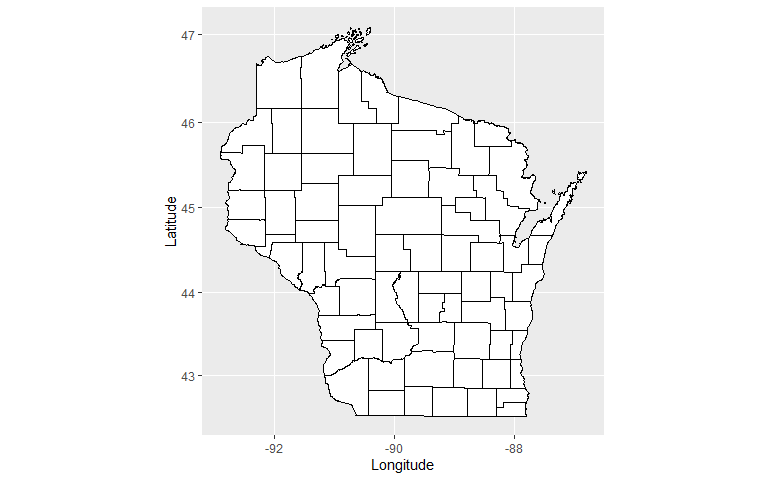

```r
p1 <- ggplot() + geom_map(data=wi_map, map=wi_map,
                    aes(x=long, y=lat, map_id=id),
                    color="black", fill="white", size=0.25) +
    coord_map() +
    ylab("Latitude") +
    xlab("Longitude")
p1
```

## Preparing the Data

Next, we simulate some data. For this example, we imagine that in each county there were a total number of people sampled (**ntrials**), some of which have outcome *X* (**ncases**). We assume the total number of people sampled come from a negative binomial distribution and use `rnbinom()` to simulate **ntrials**. We assume cases follow a binomial distribution and use `rbinom()` to draw cases from the population with probability $\pi$. For illustration of `clusso`, we put a cluster with elevated rates in Wood, Portage, Waushera, Adams, Juneau, and Marquette counties. We will only be looking at space for this example so there is only a single time period.

```r
#create ncases and ntrials for 72 counties in Wisconsin
set.seed(2)
ncounties <- length(unique(wi@data$NAME))
ntrials <- rnbinom(n=ncounties, mu=1000, size =10)
dat <- cbind.data.frame(id=unique(wi@data$NAME),ntrials)
dat <- dat %>%
    mutate(ncases = if_else(id %in% c("Wood", "Portage", "Waushara", "Adams", "Juneau","Marquette"),
                            rbinom(ncounties,ntrials, 0.9),
                            rbinom(ncounties,ntrials, 0.1)),
           time = "Period1")
str(dat)
```

```
## 'data.frame':    72 obs. of  4 variables:
##  $ id     : chr  "Ashland" "Grant" "Sawyer" "Crawford" ...
##  $ ntrials: num  668 636 737 743 1262 ...
##  $ ncases : int  71 66 60 67 106 67 131 89 54 680 ...
##  $ time   : chr  "Period1" "Period1" "Period1" "Period1" ...
```

The dataframe `dat`, that contains the county name (*id*), number of people sampled (*ntrials*), number of people with outcome *X* (*ncases*), and number of time periods (*time*).

Next, we need to merge `dat` with the `SpatialPolygonsDataFrame`, `wi`. We use `merge()` from the `sp` package to combine the two by county name (county name is the variable *NAME* in `wi` and is *id* in `dat`).

```r
#merge to map
widat <-  sp::merge(wi,dat, by.x="NAME", by.y="id", duplicateGeoms=TRUE)
class(widat)
```

```
## [1] "SpatialPolygonsDataFrame"
## attr(,"package")
## [1] "sp"
```

```r
head(widat)
```

```
##        NAME STATEFP COUNTYFP COUNTYNS       AFFGEOID GEOID LSAD      ALAND
## 2   Ashland      55      003 01581061 0500000US55003 55003   06 2706476264
## 22    Grant      55      043 01581081 0500000US55043 55043   06 2970403781
## 57   Sawyer      55      113 01581116 0500000US55113 55113   06 3257216619
## 12 Crawford      55      023 01581071 0500000US55023 55023   06 1477970887
## 19 Florence      55      037 01581078 0500000US55037 55037   06 1264232458
## 26     Iron      55      051 01581085 0500000US55051 55051   06 1963699141
##        AWATER ntrials ncases    time
## 2  3230710864     668     71 Period1
## 22   94520011     636     66 Period1
## 57  239883874     737     60 Period1
## 12   73976438     743     67 Period1
## 19   24111636    1262    106 Period1
## 26  416924548     773     67 Period1
```

In order to extract the centroid from each county, we first convert our new `SpatialPolygonsDataFrame` to a simple features (*sf*) object using `st_as_sf()` from the `sf` package. It is possible to extract centroids from the `SpatialPolygonsDataFrame`, but we do so here in order to also illustrate the `sf` package:

```r
#convert to simple features sf
widatsf <- st_as_sf(widat)
class(widatsf)
```

```
## [1] "sf"         "data.frame"
```

To prepare `widatsf` for use with `clusso()`, we convert `time` and `NAME` to factors:

```r
widatsf$time <- as.factor(widatsf$time)
widatsf$NAME <- as.factor(widatsf$NAME)
```

We extract the centroids using `st_centroid()` and extract the coordinates using `st_coordinates()`; both functions are from the `sf` package.

```r
coords <- as.data.frame(st_coordinates(st_centroid(widatsf)))
head(coords)
```

```
##           X        Y
## 1 -90.67794 46.31608
## 2 -90.70620 42.86748
## 3 -91.14454 45.87998
## 4 -90.93104 43.23947
## 5 -88.39810 45.84846
## 6 -90.24206 46.26227
```

We can plot the centroids on top of the base map we created above, *p1*:

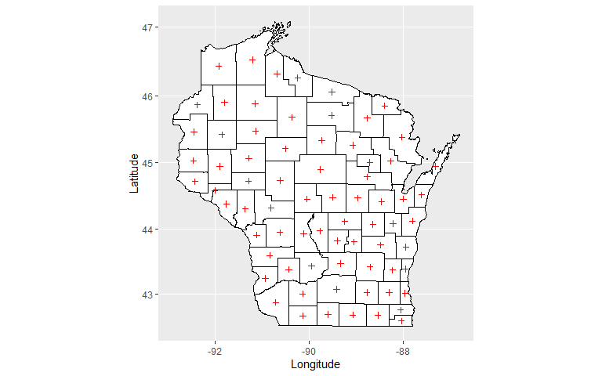

```r
p1 + geom_point(data=coords,aes(x=X, y=Y), color="red", shape=3)
```

We can visualize the proportion of cases from the total number of trials by creating a new variable, `prop`:

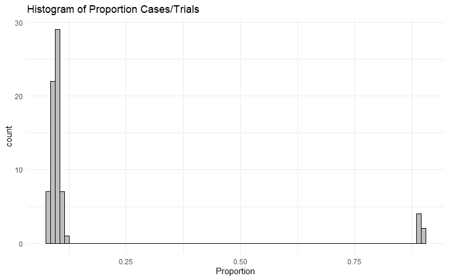

```r
widatsf <- widatsf %>%
    mutate(prop = ncases/ntrials)

ggplot(data=widatsf) +
    geom_histogram(aes(x=prop),binwidth = 0.01,
                   fill="grey", color="black") +
    theme_minimal() +
    xlab("Proportion") +
    ggtitle("Histogram of Proportion Cases/Trials")
```

We visualize the proportion on the Wisconsin map. We take the natural log of the proportion to better see small differences at the lower end in the proportion:

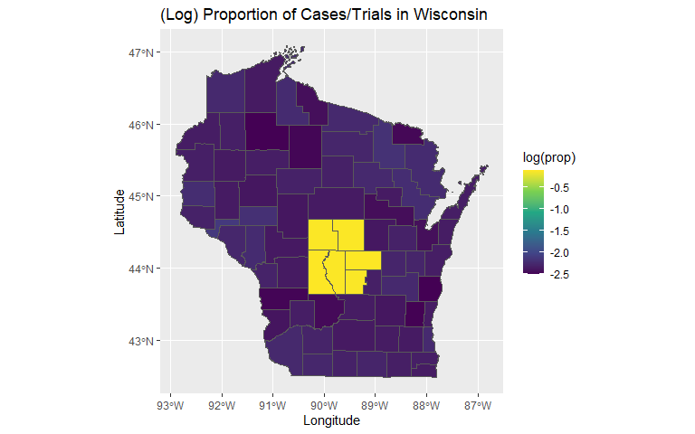

```r
ggplot(widatsf) +
    geom_sf(aes(fill=log(prop))) +
    scale_fill_viridis_c() +
    xlab("Longitude") +
    ylab("Latitude") +
    ggtitle("(Log) Proportion of Cases/Trials in Wisconsin")
```

## Using `clusso`

We first set global parameters, namely the maximum radius size for each potential cluster (`rMax <- 100`), the number of time periods to 1 (`Time <- 1`). We also extract our *x* and *y* coordinates, which are in longitude and latitude, and set them as `xx` and `yy`.

To perform the regularized spatial and spatio-temporal cluster detection using the Lasso penalty, we use the function `clusso()`. In the first argument, we set the name of the dataframe, `df=widatsf`. In the second argument we set `expected` counts equal to the total number of trials in the `widatsf` dataframe (`expected = ntrials`). In the third argument, we set the observed counts equal to the total number of cases in each county in the `widatsf` dataframe (`observed = ncases`). In the fourth argument, we set the timeperiod equal to the name of the time periods in the `widatsf` dataframe (`timeperiod = time`). In this example, we do not want to include other covariates as un-penalized terms in the model so we set `covars = FALSE`.

The next two arguments are `x` and `y`, which are the longitude and latitude for each centroids. Since these are longitude and latitude coordinates, we also set `utm=FALSE`. This will tell `clusso` to use the *great-circle-distance* or *Haversine* distance to calculate the distance between a centroid up to `rMax`.

The next argument is the maximum radius (in km) for the potential clusters. We set `rMax = rMax`, which we defined above as 100km. The argument `utm` specifies that our coordinates are *NOT* in UTM coordinates (`utm = FALSE`). The is `analysis` argument defines the type of analysis to be performed. Options include `space`, `spacetime`, or `both`. Here, we set `analysis` equal to `space`, which will perform only the spatial analysis. The argument `model` is the type of model to be used. In this example, we specify the *binomial* model. The argument `maxclust` is the maximum number of actual clusters expected in the given area. This is based on scientific knowledge of the area. For this dataset, we set `maxclust=15`. If the number of identified clusters exceeds `maxclust`, a warning will encourage you to increase your set `maxclust`.

The output of `clusso()` is assigned to the object `resclusso`. `resclusso` is a large list of lists. The recommended way to explore the results is to explore the `names(resreal)` and select each sub-list of interest.

```r
rMax <- 100
Time <- 1

xx <- coords$X
yy <- coords$Y



resclusso <- clusso(df=widatsf,
                    expected = ntrials,
                    observed = ncases,
                    timeperiod = time,
                    id = NAME,
                    covars = FALSE,
                    x= xx,
                    y= yy,
                    rMax = rMax,
                    utm=FALSE,
                    analysis = "space",
                    model="binomial",
                    maxclust = 15, collapsetime = TRUE)
clussopretty(resclusso, analysis="space", model="binomial",clusteridentify=FALSE)
```

```
##            model analysistype numclust.AIC numclust.AICc numclust.BIC
## 1       Binomial        Space           17            17           17
## 2 Quasi-Binomial        Space           16            16           13
```

## Plotting `clusso` Results on the Map

We set the max and min relative risk for the color scheme using `maxrr` and `minrr`. You may want to explore these values depending on the presentation you are using (a shortened maxrr, minrr distance will bring colors in closer and maps on a projector will appear more vivid and darker).

We extract the relative risk estimates using BIC from `resclusso$lassoresult.p.s$E.qbic` and then use `redblue()` to map the estimated relative risks to colors.

```r
maxrr <- 10
minrr <- 0.1
estrr.bic <- resclusso$lassoresult.p.s$E.qbic
cluster_ix <- redblue(log(maxrr *  pmax(minrr, pmin(estrr.bic, maxrr)))/log(maxrr^2))
table(cluster_ix)
```

```
## cluster_ix
## #063365 #124A86 #1D5FA2 #2166AC #266CAF #3681BA #3783BB #3885BB #408FC1 #4493C3
##       1       1       1       2       1       2       3       2       3       1
## #4594C4 #4795C4 #4996C5 #4D99C6 #4E99C6 #4E9AC6 #539DC8 #5DA3CC #62A7CD #67AACF
##       3       1       1       4       1       7       4       2       1       1
## #6EAED1 #7CB7D6 #86BDDA #87BEDA #8BC0DB #91C4DD #97C7DF #9FCBE1 #A8D0E4 #BDDBEA
##       1       2       1       3       5       4       1       3       1       1
## #F2F4F6 #F6F6F6 #F8BDA0
##       1       1       6
```

Next, we combine the estimated relative risks (`resclusso$lassoresult.p.s$E.qbic`), county names (`widatsf$NAME`), and mapped colors (`cluster_ix`) into the dataframe `rr.bic`. We map the county names onto the colors (`names(cluster_ix) <- rr.bic$county`).

```r
rr.bic <- cbind.data.frame(rr=resclusso$lassoresult.p.s$E.qbic,
                           county=widatsf$NAME,
                           colors = cluster_ix)
names(cluster_ix) <- rr.bic$county
```

We merge the dataframe `rr.bic` to the `SpatialPolygonsDataFrame`, `wi`, by county name and convert it to a simple features dataframe for use with `ggplot2`.

```r
merged.bic<- sp::merge(wi,rr.bic, by.x="NAME", by.y="county", duplicateGeoms=TRUE)
datdf.bic <- st_as_sf(merged.bic)
```

Finally, we use `geom_sf()` to plot the estimated relative risks onto the map. We use the aesthetic (`aes(fill=NAME)`) and `scale_fill_manual(values=cluster_ix)` to plot our pre-defined colors onto the map.

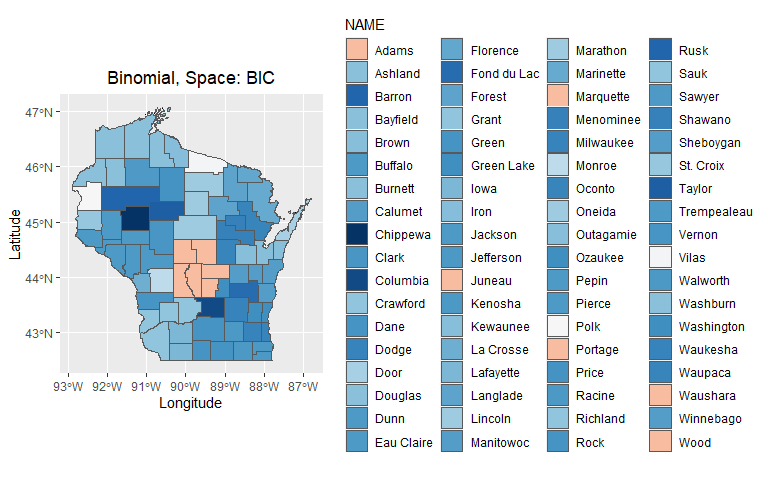

```r
p1+ geom_sf(data=datdf.bic, aes(fill=NAME)) +
    scale_colour_manual(values = c("red", "blue", "green")) +
    scale_fill_manual(values=cluster_ix)+
    theme(plot.title = element_text(hjust=0.5)) +
    ggtitle("Binomial, Space: BIC")
```

For a simpler map, we can also isolate the counties with relative risks greater than 1 and only outline county edges with red:

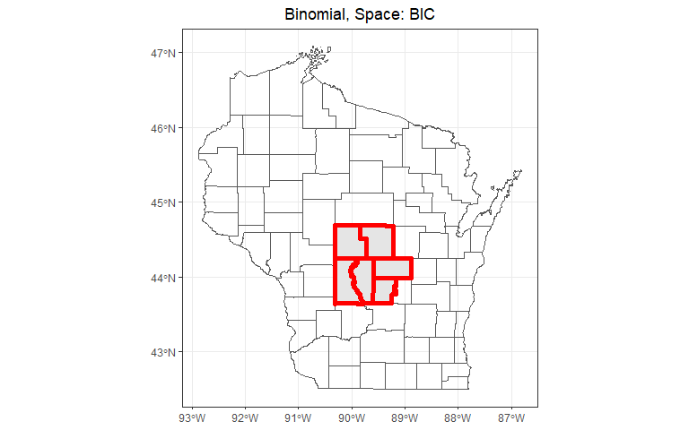

```r
ggplot()+ geom_sf(data=datdf.bic, lwd=0, fill='transparent') +
    geom_sf(data=subset(datdf.bic, rr>1), color="red", size=2) +
    theme_bw()+
    theme(legend.position = "none",
          plot.title = element_text(hjust=0.5)) +
    ggtitle("Binomial, Space: BIC")
```